# SDS/CSC 293 Mini-Project 1: Splines

## Visualize your model on training data

Visualize your fitted splines model $\widehat{f}()$ with degrees of freedom `df_star` on the training data. Recall we can only create this plot for the training data because we only have the outcome variable $y$ for the training data.

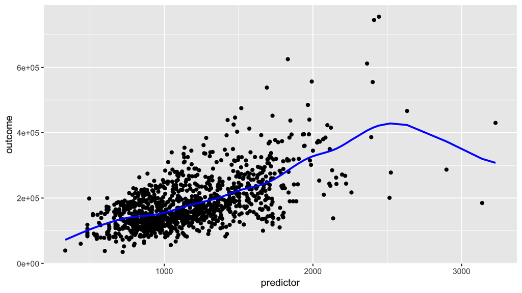

```r
# fit each pretend training set a spline model, extract data frame of info based on fitted model, and plot fitted model on each pretend training data

# model 1
model1_points <- model1 %>%
  broom::augment()
training_plot1 <- ggplot(ptrain1, aes(x = predictor, y = outcome)) +
  geom_point()
training_plot1 +
  geom_line(data = model1_points, aes(x = x, y = .fitted), col = "blue", size = 1)
```

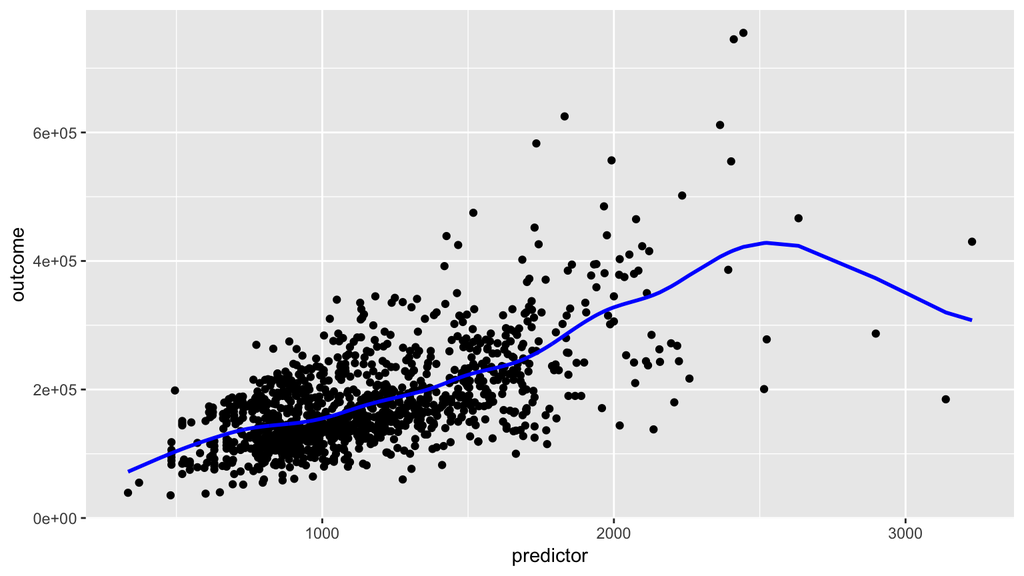

```r
# same for other models - model 2
model2_points <- model2 %>%
  broom::augment()
training_plot2 <- ggplot(ptrain2, aes(x = predictor, y = outcome)) +
  geom_point()
training_plot2 +
  geom_line(data = model1_points, aes(x = x, y = .fitted), col = "blue", size = 1)
```

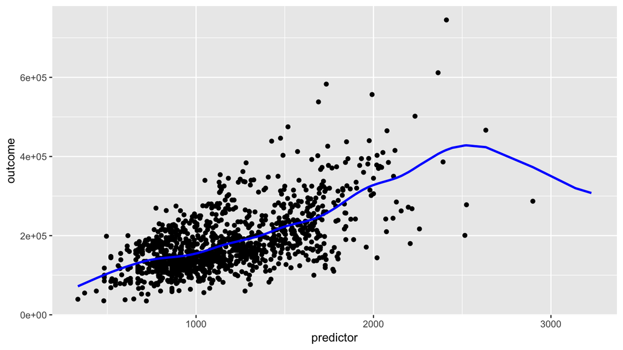

```r
# model 3
model3_points <- model3 %>%
  broom::augment()
training_plot3 <- ggplot(ptrain3, aes(x = predictor, y = outcome)) +
  geom_point()
training_plot3 +
  geom_line(data = model1_points, aes(x = x, y = .fitted), col = "blue", size = 1)
```

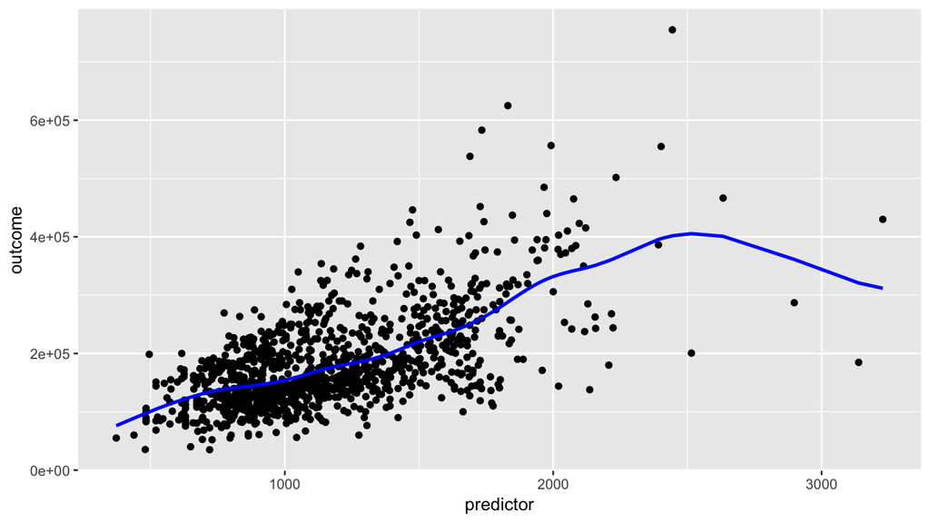

```r
# model 4
model4_points <- model4 %>%
  broom::augment()
training_plot4 <- ggplot(ptrain4, aes(x = predictor, y = outcome)) +
  geom_point()
training_plot4 +
  geom_line(data = model4_points, aes(x = x, y = .fitted), col = "blue", size = 1)
```

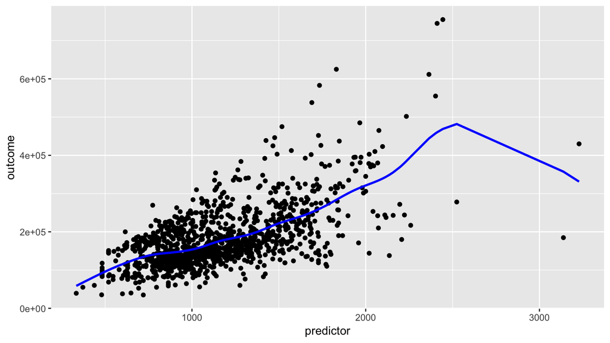

```r
# model 5
model5_points <- model5 %>%
  broom::augment()
training_plot5 <- ggplot(ptrain5, aes(x = predictor, y = outcome)) +
  geom_point()
training_plot5 +
  geom_line(data = model5_points, aes(x = x, y = .fitted), col = "blue", size = 1)
```

## Make predictions on test data

Make your predictions/get your predicted values $\widehat{y}$ on the test data.

### Step 2: Make predictions on test data by applying fitted spline model & plot

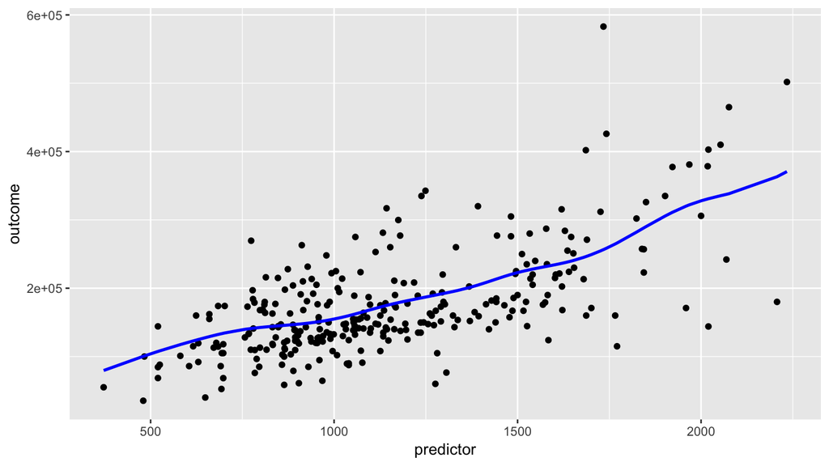

```r
# model 1
predicted_points1 <- predict(model1, x = ptest1$predictor) %>%
  as.tibble()
ggplot()+
  geom_point(data = ptest1, aes(x = predictor, y = outcome)) +
  geom_line(data = predicted_points1, aes(x = x, y = y), col = "blue", size = 1)
```

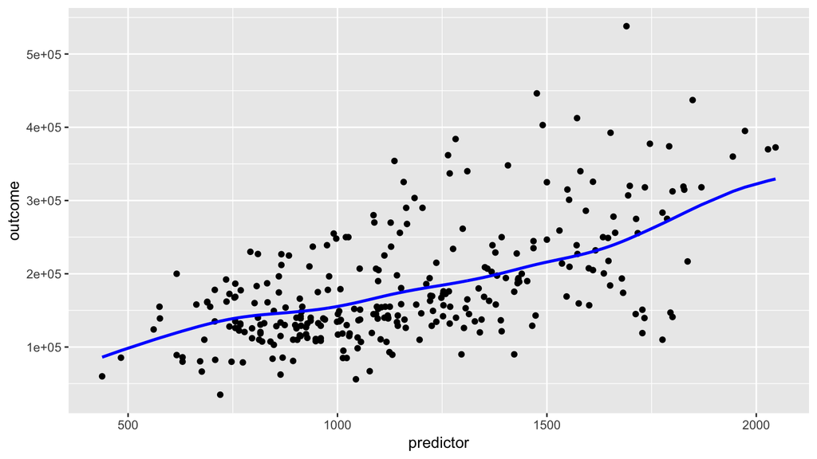

```r
# model 2
predicted_points2 <- predict(model2, x = ptest2$predictor) %>%
  as.tibble()
ggplot()+
  geom_point(data = ptest2, aes(x = predictor, y = outcome)) +
  geom_line(data = predicted_points2, aes(x = x, y = y), col = "blue", size = 1)
```

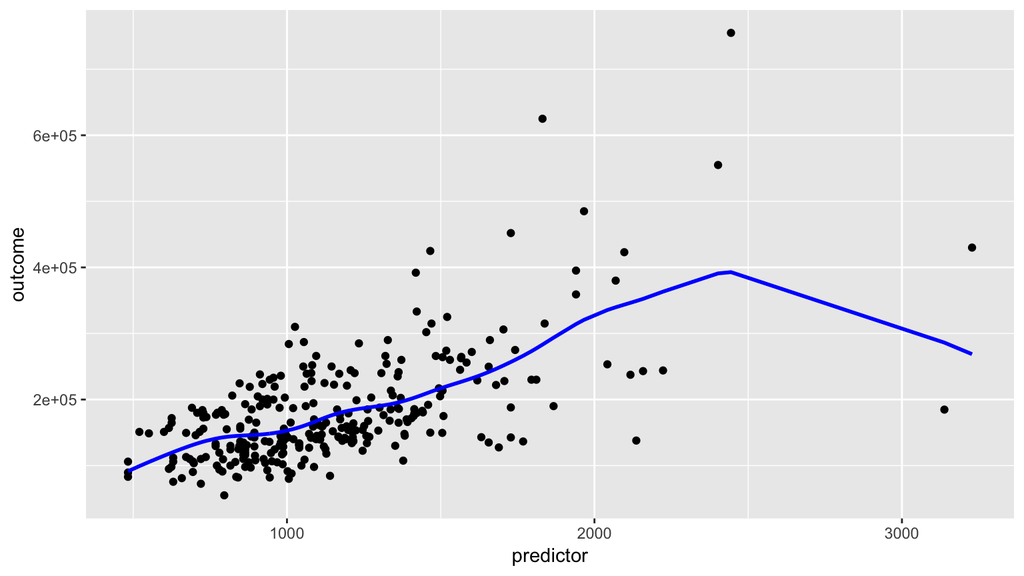

```r
# model 3
predicted_points3 <- predict(model3, x = ptest3$predictor) %>%
  as.tibble()
ggplot()+
  geom_point(data = ptest3, aes(x = predictor, y = outcome)) +
  geom_line(data = predicted_points3, aes(x = x, y = y), col = "blue", size = 1)
```

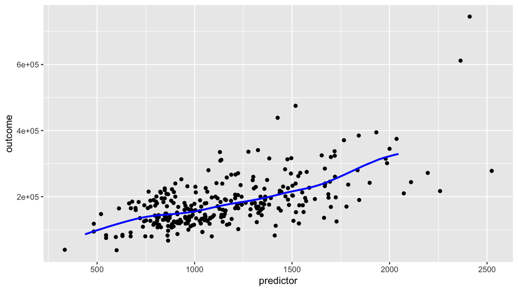

```r
# model 4
predicted_points4 <- predict(model4, x = ptest4$predictor) %>%
  as.tibble()
ggplot()+
  geom_point(data = ptest4, aes(x = predictor, y = outcome)) +
  geom_line(data = predicted_points2, aes(x = x, y = y), col = "blue", size = 1)
```

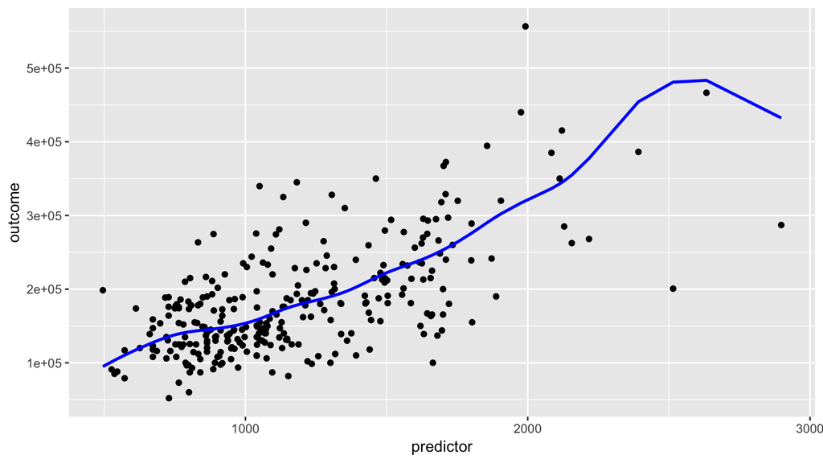

```r
# model 5
predicted_points5 <- predict(model5, x = ptest5$predictor) %>%
  as.tibble()
ggplot()+
  geom_point(data = ptest5, aes(x = predictor, y = outcome)) +
  geom_line(data = predicted_points5, aes(x = x, y = y), col = "blue", size = 1)
```

### Step 3: Calculate RMLSE for each model

```r
# add predicted values to pretend test set to compare predicted values and actual outcome and calculate RMLSE
ptest1$predicted <- predicted_points1$y
ptest2$predicted <- predicted_points2$y
ptest3$predicted <- predicted_points3$y
ptest4$predicted <- predicted_points4$y
ptest5$predicted <- predicted_points5$y
```

```r
# mod 1
e1 <- ptest1%>%
  mutate(lgout = log(outcome+1),
         lgprd = log(predicted+1),
         lgres = lgout - lgprd,
         lgres_sqr = lgres^2) %>%
  summarize(sle = mean(lgres_sqr)) %>%
  mutate(rmlse = sqrt(sle))

# mod 2
e2 <- ptest2 %>%
  mutate(lgout = log(outcome+1),
         lgprd = log(predicted+1),
         lgres = lgout - lgprd,
         lgres_sqr = lgres^2) %>%
  summarize(sle = mean(lgres_sqr)) %>%
  mutate(rmlse = sqrt(sle))

# mod 3
e3 <- ptest3 %>%
  mutate(lgout = log(outcome+1),
         lgprd = log(predicted+1),
         lgres = lgout - lgprd,
         lgres_sqr = lgres^2) %>%
  summarize(sle = mean(lgres_sqr)) %>%
  mutate(rmlse = sqrt(sle))

# mod 4
e4 <- ptest4 %>%
  mutate(lgout = log(outcome+1),
         lgprd = log(predicted+1),
         lgres = lgout - lgprd,
         lgres_sqr = lgres^2) %>%
  summarize(sle = mean(lgres_sqr)) %>%
  mutate(rmlse = sqrt(sle))

# mod 5
e5 <- ptest5 %>%
  mutate(lgout = log(outcome+1),
         lgprd = log(predicted+1),
         lgres = lgout - lgprd,
         lgres_sqr = lgres^2) %>%
  summarize(sle = mean(lgres_sqr)) %>%
  mutate(rmlse = sqrt(sle))

rmlse <- rbind(e1, e2, e3, e4, e5) %>%
  mutate(model_number = c(1, 2, 3, 4, 5)) %>%
  select(model_number, rmlse)
rmlse
```

| model_number | rmlse |
| --- | --- |
| 1 | 0.3268641 |
| 2 | 0.3415370 |
| 3 | 0.3057332 |
| 4 | 0.3016664 |
| 5 | 0.3019795 |

```r
mean_rmlse <- mean(rmlse$rmlse)
mean_rmlse
```

```
## [1] 0.3155561
```

# Submission

## Create your submission CSV

The following code creates a submission where the predicted sale price for all houses in the test set is just the average sale price of the training data. Change the code so that you are submitted your spline model fitted predictions.

```r
submission <- sample_submission %>%
  mutate(SalePrice =  mean(training$SalePrice))

write_csv(submission, path = "data/submission.csv")
```

## Screenshot of your Kaggle score

The “Root Mean Squared Logarithmic Error” score based on my example submission was 0.42918. Replace `score_screenshot.png` with a screenshot of your score.

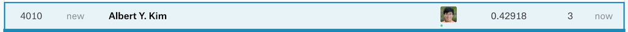